# Single-cell methylation analysis notebook

Davis McCarthy, EMBL-EBI

2017-04-30

# 1 Introduction to notebooks

Executing a chunk by clicking the *Run* button within the chunk or by placing your cursor inside it and pressing *Cmd+Shift+Enter*.

# 2 Preparation for analysis

## 2.1 Load libraries

```r
library(tidyverse)
```

## 2.2 Load summarized data

Load the summarized results in `../results/all.tsv.gz`.

```r
df <- read_tsv("../results/archive/all.tsv.gz")
df <- read_tsv("../results/archive/all.tsv.gz")
df <- mutate(df, sample = gsub(".tsv.gz", "", sample))
```

Add sample metadata defining cell type.

```r
df_meta <- read_delim("../data/sample_metadata.txt", col_names = FALSE, delim = " ")
```

Add cell type information to methylation data frame.

| sample | id | anno | rate | weight | cell_type |
| --- | --- | --- | --- | --- | --- |
| 3289STDY6312182 | active_enhancers_100 | active_enhancers | 0 | 9 | E4.5 |
| 3289STDY6312182 | active_enhancers_1000 | active_enhancers | 0 | 1 | E4.5 |
| 3289STDY6312182 | active_enhancers_1001 | active_enhancers | 0 | 13 | E4.5 |
| 3289STDY6312182 | active_enhancers_1008 | active_enhancers | 0 | 2 | E4.5 |
| 3289STDY6312182 | active_enhancers_1012 | active_enhancers | 0 | 9 | E4.5 |
| 3289STDY6312182 | active_enhancers_1013 | active_enhancers | 0 | 4 | E4.5 |

# 3 Clustering of cells by methylation profile

We can take just the methylation rates for the active enhancer features and use probabilistic PCA (which can handle missing values; highly relevant here) to view cells in a lower-dimensional space. Here we only use enhancers with less than 50% missing values

```r
summary(prop_na)
```

```
   Min. 1st Qu.  Median    Mean 3rd Qu.    Max.
 0.0000  0.4000  0.5333  0.5341  0.6667  0.9333
```

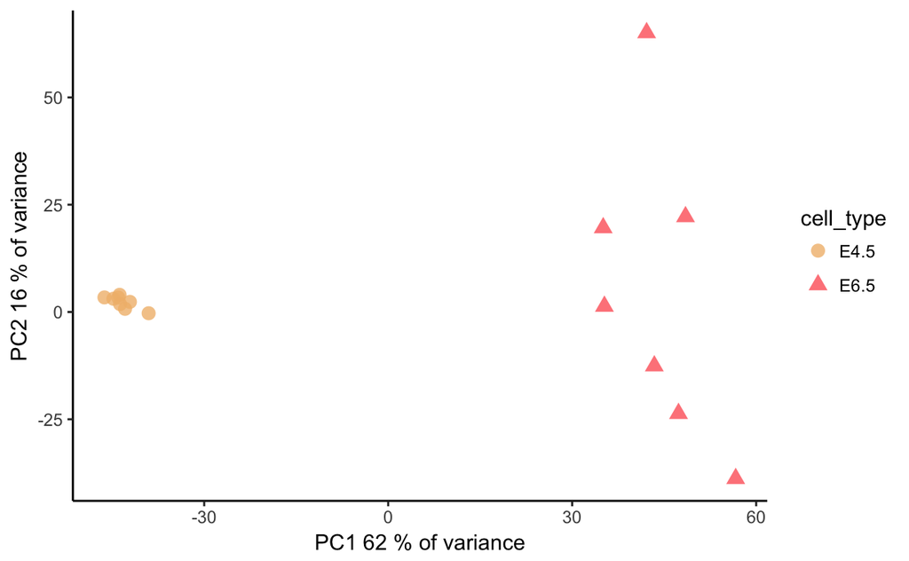

Here, the first principal component separates the cells by cell type (E4.5 and E6.5).

**EXERCISE:** Repeat this with other classes of features. Do you see the same results?

# 4 Context specificity of methylation

## 4.1 Mean and variance of methylation rate

Functionality from the `dplyr` package makes it easy to compute the mean and variance of the methylation rate across annotation categories.

### 4.1.1 Mean and variance of methylation rate across all cells

Plotting the distributions of mean methylation rate across genomic features reveals that promoters and CpG islands are generally very lowly methylated, whereas repetetive elements (IAP) are frequently highly methylated. Enhancer regions commonly have moderate (25-50%) methylation.

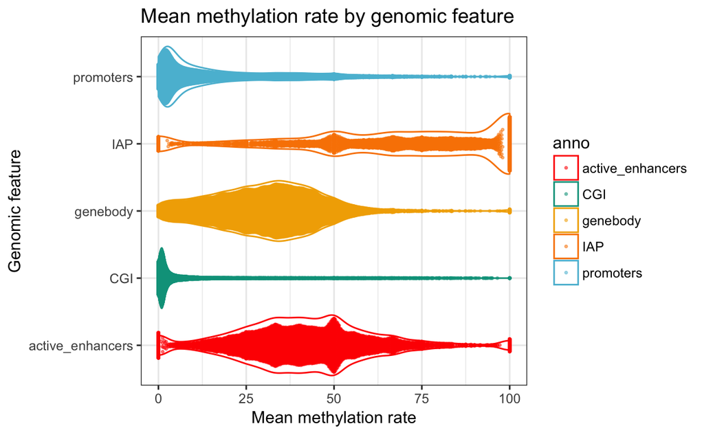

We can also examine the variance of methylation rate across classes of genomic feature. Plotting the distributions of the standard deviation of methylation rate by type of feature reveals that promoters and CpG islands typically have low variance of methylation rate, whereas methylation rate genebody and active enhancers is highly variable. IAP elements have widely varying standard deviations: some elements have very low variance in methylation rate, while others have very high variance.

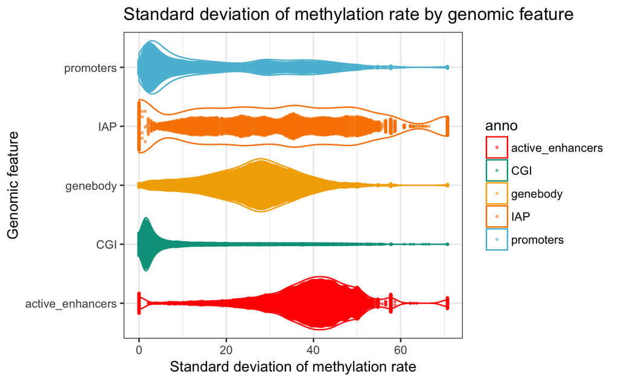

### 4.1.2 Mean and variance of methylation rate by cell type

When we compute the mean methylation rate separately for the two cell types (E4.5 and E6.5), we see stark differences in the distributions of mean methylation rate across genomic features. Particularly, active enhancers go from almost completely unmethylated in E4.5 cells to highly methylated (most active enhancers greater than 50% methylated) in E6.5 cells. Similarly, gene bodies are generally much more methylated in E6.5 cells than E4.5 cells.

In both cell types CpG islands are generally very lowly methylated, whereas repetetive elements (IAP) are consistently highly methylated in E6.5 cells, but show high variation in mean methylation rate in E4.5 cells. Promoters are generally lowly methylated, but show slightly more methylation in E6.5 cells.

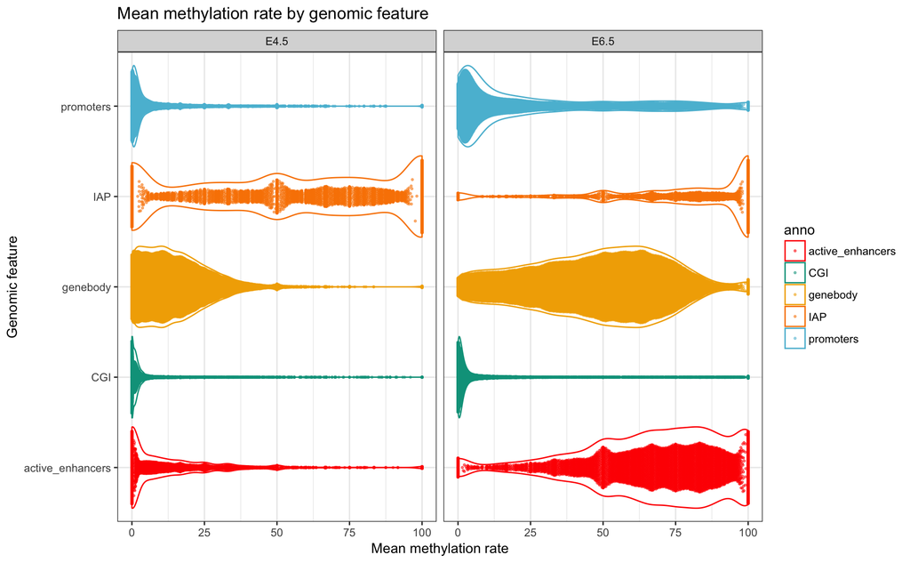

Examination of the variance of methylation rate across classes of genomic feature split by cell type shows similar patterns to the mean methylation rate. Genebody and active enhancer methylation variance is higher in E6.5 cells than E4.5 cells. IAP features are generally have less variable methylation in E6.5 cells; in E4.5 cells, IAP elements have widely varying standard deviations: some elements have very low variance in methylation rate, while others have very high variance. Promoters have slightly higher methylation variance in E6.5 cells. In both cell types, CpG islands typically have very low variance of methylation rate.

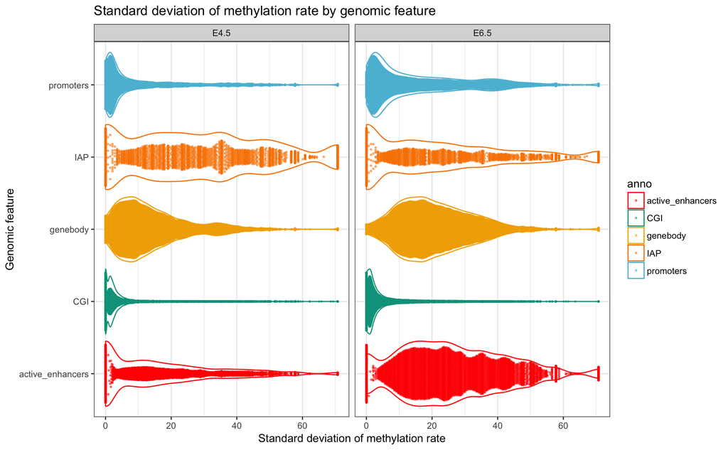

These analyses demonstrate the context specificity of methylation variance. In mouse ES cells, CGIs are homogenous (and low in methylation), repeat elements are homogenously high in E6.5 cells and active enhancer elements are heterogeneous. This is interesting because the enhancer elements are cell type specific and thus some variation in the methylation levels here implies plasticity in cell identity which could be important for lineage formation.